# Early anslysis: covid data

```r
library(tidyverse)
library(stargazer)
library(sjPlot)
library(lubridate)
library(stringi)
library(fixest)

tweet_data <- read.csv(here::here("Read only (do not track)", "20210303_tweets_with_covariates.csv"))

##Created at as date
tweet_data <- tweet_data %>% mutate(created_at = ymd_hms(created_at))

##Number of words per string
tweet_data <- tweet_data %>% mutate(n.words = str_count(text, boundary("word")))

##Emotion words divided by word length
tweet_data <- tweet_data %>% mutate(anger.prop = NRC.10.anger / n.words)
tweet_data <- tweet_data %>% mutate(trust.prop = NRC.10.trust / n.words)
tweet_data <- tweet_data %>% mutate(anticip.prop = NRC.10.anticipation / n.words)
tweet_data <- tweet_data %>% mutate(disgust.prop = NRC.10.disgust / n.words)
tweet_data <- tweet_data %>% mutate(fear.prop = NRC.10.fear / n.words)
tweet_data <- tweet_data %>% mutate(joy.prop = NRC.10.joy / n.words)
tweet_data <- tweet_data %>% mutate(sad.prop = NRC.10.sadness / n.words)
tweet_data <- tweet_data %>% mutate(surprise.prop = NRC.10.surprise / n.words)


##Economy tweets

tweet_data <- tweet_data %>% mutate(economy_tweet = ifelse(grepl("business* | jobs | economy | reopen* | opening | relaunch | restart | workforce | economic | easing restrictions | operate | owners | recover*", tweet_data$text) == TRUE, 1, 0))

##Removing epidemic tweets (because 'gun violence epidemic' is common phrase)

tweet_data <- tweet_data %>% mutate(text.lower = tolower(text))


#tweet_data <- tweet_data %>% mutate(gun_tweet = ifelse(grepl("gun", tweet_data$text) == TRUE, 1, 0))
#tweet_data <- tweet_data %>% filter(gun_tweet == 0)

tweet_data <- tweet_data %>% mutate(epidemic_tweet = ifelse(grepl("epidemic", tweet_data$text.lower) == TRUE, 1, 0))
tweet_data <- tweet_data %>% filter(epidemic_tweet == 0)

#tweet_data <- tweet_data %>% select(-text.lower)

##Cases and deaths per capita

tweet_data <- tweet_data %>% mutate(cases_pc = as.numeric(cases) / pop2019)
tweet_data <- tweet_data %>% mutate(deaths_pc = as.numeric(deaths) / pop2019)

###NOTE: There is an issue with a smallish number of units having no screenname, and duplicated rows. The rows are duplicated because there are two entries for each unit for the cases and deaths data. This should be de-bugged, but for now, I exclude them -- CH

tweet_data <- tweet_data %>% filter(is.na(screen_name_lower)==F)

##Changing 'W' to 'F'

tweet_data <- tweet_data %>% mutate(gender = factor(ifelse(gender == "W", "F", gender)))

##Screen name lower as factor

tweet_data <- tweet_data %>% mutate(screen_name_lower = factor(screen_name_lower))
```

##GLM Poisson model for testing dispersion

```r
AER::dispersiontest(model_anger_p, alternative = "greater")
```

```
    Overdispersion test

data:  model_anger_p
z = 8.2333, p-value < 2.2e-16
alternative hypothesis: true dispersion is greater than 1
sample estimates:
dispersion
  8186.979
```

##Looking at how people respond to anger and trust by gender and party

Note: There are no significant interaction effects for party * gender * emotion for either anger or trust

```r
model_anger_type <- lm(favorite_count ~ gender*NRC.10.anger + NRC.10.anticipation + NRC.10.disgust + NRC.10.fear + NRC.10.joy + NRC.10.sadness + NRC.10.surprise + NRC.10.trust + cases_pc + deaths_pc + state2 + retweet_count + party + followers_count + type + economy_tweet + n.words, data = tweet_data %>% filter(party == "Republican" | party == "Democrat"))
stargazer(model_anger_type, type = "text")
```

```
length of NULL cannot be changedlength of NULL cannot be changedlength of NULL cannot be changedlength of NULL cannot be changedlength of NULL cannot be changed
```

```
================================================
                         Dependent variable:
                     ---------------------------
                           favorite_count
------------------------------------------------
genderM                        95.618*
                              (50.898)

NRC.10.anger                 210.519***
                              (49.508)

NRC.10.anticipation            -7.209
                              (21.497)

NRC.10.disgust                  5.982
                              (39.512)

NRC.10.fear                    24.458
                              (23.636)

NRC.10.joy                   -107.779***
                              (29.257)

NRC.10.sadness                 24.550
                              (26.266)

NRC.10.surprise              125.924***
                              (33.376)

NRC.10.trust                 111.703***
                              (17.181)

cases_pc                     4,389.680*
                             (2,307.858)

deaths_pc                    113,416.900
                            (85,388.390)

state2AL                       163.471
                              (325.153)
```

[output cut: 177 more lines]

```

genderM:NRC.10.anger         -172.949***
                              (53.887)

Constant                       212.458
                              (285.544)

------------------------------------------------
Observations                   58,201
R2                              0.180
Adjusted R2                     0.179
Residual Std. Error    4,139.036 (df = 58128)
F Statistic          177.179*** (df = 72; 58128)
================================================
Note:                *p<0.1; **p<0.05; ***p<0.01
```

Anger plots

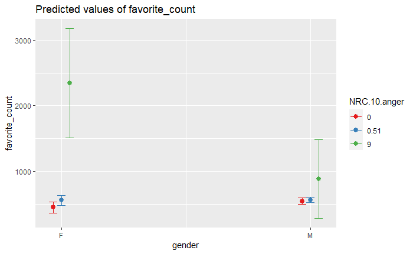

```r
plot_model(model_anger_type, type = "eff", terms = c("gender", "NRC.10.anger[0, .51, 9]")) #[min, mean, max]
```

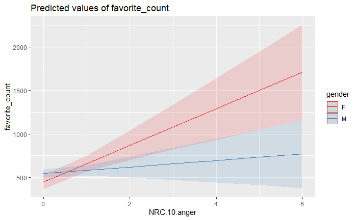

```r
plot_model(model_anger_type, type = "eff", terms = c("NRC.10.anger", "gender")) #[min, mean, max]
```

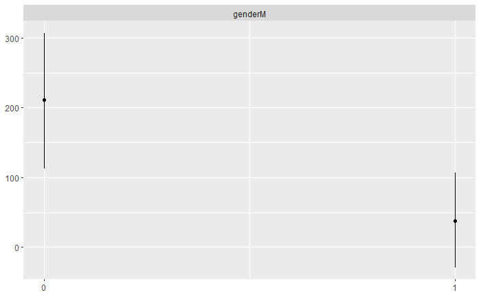

```r
interplot::interplot(model_anger_type, var2 = "gender", var1 = "NRC.10.anger")
```

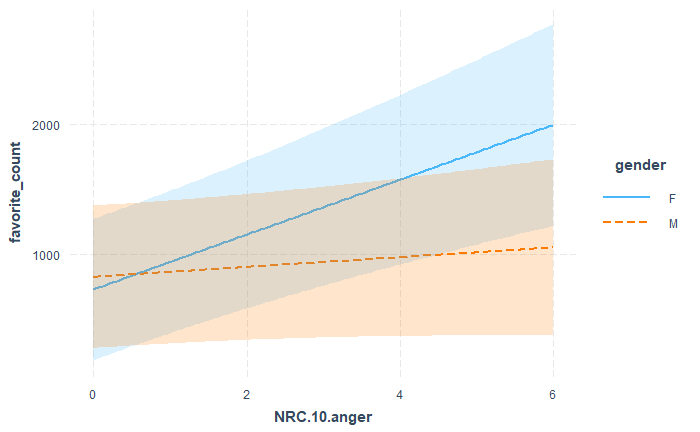

```r
interactions::interact_plot(model_anger_type, pred = "NRC.10.anger", modx = "gender", interval = T)
```

```r
NA
NA
```

###Using fixest to model fixed effects by state and role and party

```r
model_anger_nb <- MASS::glm.nb(favorite_count ~ NRC.10.anger*gender + NRC.10.anticipation + NRC.10.disgust + NRC.10.fear + NRC.10.joy + NRC.10.sadness + NRC.10.surprise + NRC.10.trust +  cases_pc + deaths_pc +  retweet_count  + economy_tweet  + n.words  + party + type + state2, data = tweet_data %>% filter(party == "Republican" | party == "Democrat"))
```

[output not shown]

[figure not shown]

```r
model_trust_type <- lm(favorite_count ~ gender*NRC.10.trust + NRC.10.anticipation + NRC.10.disgust + NRC.10.fear + NRC.10.joy + NRC.10.sadness + NRC.10.surprise + NRC.10.anger + cases_pc + deaths_pc +  retweet_count + party + followers_count + type + economy_tweet + n.words, data = tweet_data %>% filter(party == "Republican" | party == "Democrat"))
stargazer(model_trust_type, type = "text")
```

```
length of NULL cannot be changedlength of NULL cannot be changedlength of NULL cannot be changedlength of NULL cannot be changedlength of NULL cannot be changed
```

```
================================================
                         Dependent variable:
                     ---------------------------
                           favorite_count
------------------------------------------------
genderM                        79.380
                              (57.392)

NRC.10.trust                 142.992***
                              (29.004)

NRC.10.anticipation            -18.403
                              (21.572)

NRC.10.disgust                 -10.692
                              (39.666)

NRC.10.fear                     5.324
                              (23.706)

NRC.10.joy                   -101.755***
                              (29.353)

NRC.10.sadness                 37.909
                              (26.297)

NRC.10.surprise              124.994***
                              (33.487)

NRC.10.anger                 102.393***
                              (31.837)

cases_pc                    4,998.624***
                             (1,893.631)

deaths_pc                   103,179.500*
                            (54,846.530)

retweet_count                 0.375***
                               (0.005)
```

[output cut: 18 more lines]

```

genderM:NRC.10.trust           -39.389
                              (32.248)

Constant                     332.534***
                              (89.481)

------------------------------------------------
Observations                   58,201
R2                              0.170
Adjusted R2                     0.170
Residual Std. Error    4,161.243 (df = 58181)
F Statistic          628.911*** (df = 19; 58181)
================================================
Note:                *p<0.1; **p<0.05; ***p<0.01
```

Trust plots

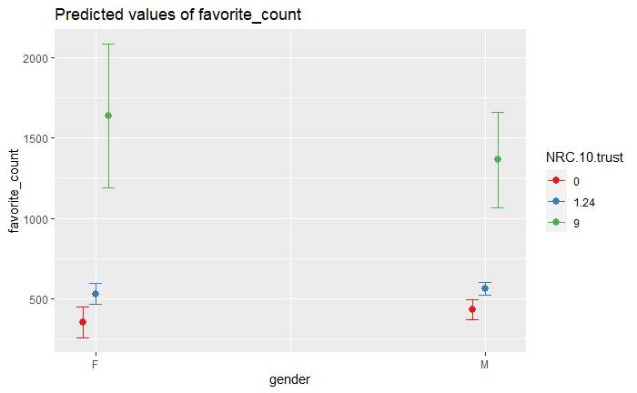

```r
plot_model(model_trust_type, type = "eff", terms = c("gender", "NRC.10.trust[0, 1.24, 9]")) #[min, mean, max]
```

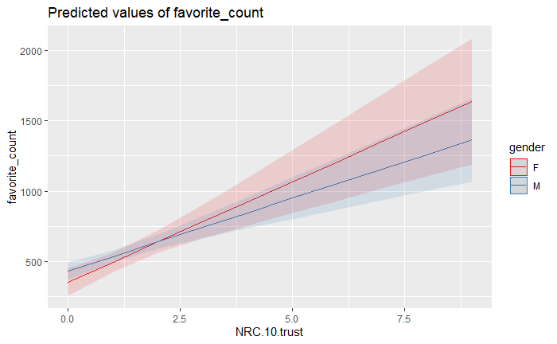

```r
plot_model(model_trust_type, type = "eff", terms = c("NRC.10.trust", "gender")) #[min, mean, max]
```

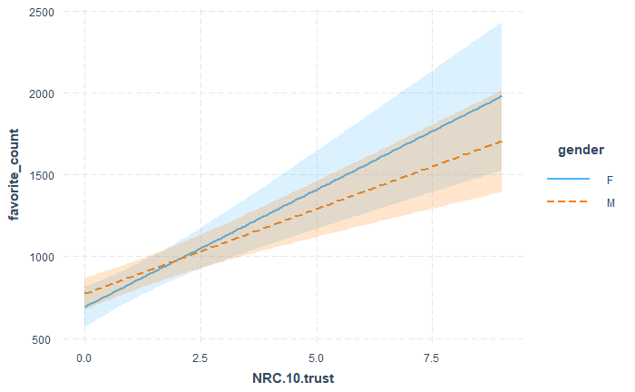

```r
interactions::interact_plot(model_trust_type, pred = "NRC.10.trust", modx = "gender", interval = T)
```

```r
NA
NA
```

##Negative binomial models

```r
model.fe.trust.nb <- femlm(favorite_count ~ NRC.10.trust + NRC.10.anticipation + NRC.10.disgust + NRC.10.fear + NRC.10.joy + NRC.10.sadness + NRC.10.surprise + NRC.10.anger +  cases_pc + deaths_pc +  retweet_count + economy_tweet + n.words + screen_name_lower, data = tweet_data, family="negbin", fixef.rm = "none")
```

```
[femlm]: The information matrix is singular: presence of collinearity. Use function collinearity() to pinpoint the problems.
```

##Testing male/female use of anger and trust Men are more willing to use anger words (as are reps and sens, compared to govs). No gender difference for trust words (reps and sens use more trust words).

```r
stargazer(model_trust_dv, type = "text", omit = c("state", "date"))
```

```
length of NULL cannot be changedlength of NULL cannot be changedlength of NULL cannot be changedlength of NULL cannot be changedlength of NULL cannot be changed
```

```
=============================================
                      Dependent variable:
                  ---------------------------
                         NRC.10.trust
---------------------------------------------
genderM                      0.015
                            (0.010)

followers_count             0.000*
                            (0.000)

cases_pc                    1.926**
                            (0.936)

deaths_pc                 -127.687***
                           (22.576)

partyRepublican            0.060***
                            (0.012)

typerep                    0.164***
                            (0.013)

typesen                    0.201***
                            (0.014)

Constant                     0.239
                            (0.362)

---------------------------------------------
Observations                58,201
Log Likelihood            -84,665.280
theta                  9.606*** (0.515)
Akaike Inf. Crit.         170,132.600
=============================================
Note:             *p<0.1; **p<0.05; ***p<0.01
```

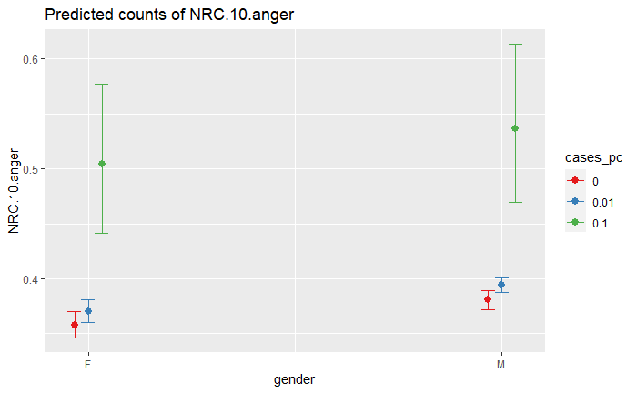

```r
plot_model(model_anger_dv, type = "eff", terms = c("gender", "cases_pc[0, .01, .1]"))
```

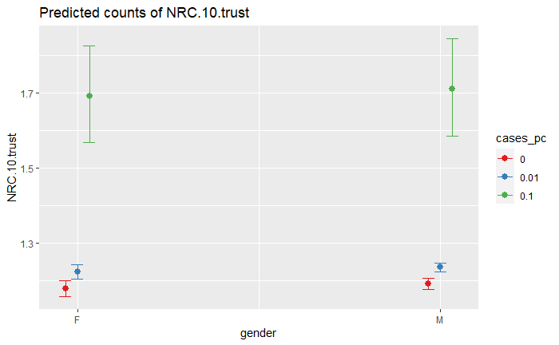

```r
plot_model(model_trust_dv, type = "eff", terms = c("gender", "cases_pc[0, .01, .1]"))
```

###Using proportions

```r
model_anger_type <- lm(favorite_count ~ gender*anger.prop + anticip.prop + disgust.prop + fear.prop + joy.prop + sad.prop + surprise.prop + trust.prop + cases_pc + deaths_pc +  retweet_count + party + followers_count + type + economy_tweet + n.words, data = tweet_data %>% filter(party == "Republican" | party == "Democrat"))
stargazer(model_anger_type, type = "text")


model_trust_type <- lm(favorite_count ~ gender*trust.prop + anger.prop + anticip.prop + disgust.prop + fear.prop + joy.prop + sad.prop + surprise.prop  + cases_pc + deaths_pc +  retweet_count + party + followers_count + type + economy_tweet + n.words, data = tweet_data %>% filter(party == "Republican" | party == "Democrat"))
stargazer(model_trust_type, type = "text")
```

Anger plots

```r
plot_model(model_anger_type, type = "eff", terms = c("gender", "anger.prop[0, 0.29]")) #[min, mean, max]
plot_model(model_anger_type, type = "eff", terms = c("anger.prop", "gender")) #[min, mean, max]

plot_model(model_trust_type, type = "eff", terms = c("gender", "trust.prop[0, 0.27]")) #[min, mean, max]
plot_model(model_trust_type, type = "eff", terms = c("trust.prop", "gender")) #[min, mean, max]
```

###Using alternative emotion datasets

Hashtag dataset has no effect for anger or trust in interaction with gender Same is true for ‘expanded’ variables

```r
model_anger_type <- lm(favorite_count ~ gender*NRC.10.Expanded.anger + NRC.10.Expanded.anticipation + NRC.10.Expanded.disgust + NRC.10.Expanded.fear + NRC.10.Expanded.joy + NRC.10.Expanded.sadness + NRC.10.Expanded.surprise + NRC.10.Expanded.trust + cases_pc + deaths_pc +  retweet_count + followers_count + party + type + economy_tweet + n.words, data = tweet_data)
stargazer(model_anger_type, type = "text")

model_anger_indfe <- lm(favorite_count ~ gender*NRC.10.Expanded.anger + NRC.10.Expanded.anticipation + NRC.10.Expanded.disgust + NRC.10.Expanded.fear + NRC.10.Expanded.joy + NRC.10.Expanded.sadness + NRC.10.Expanded.surprise + NRC.10.Expanded.trust +  cases_pc + deaths_pc +  retweet_count + economy_tweet + as.factor(screen_name_lower) + n.words, data = tweet_data)
stargazer(model_anger_indfe, omit = "screen_name", type = "text")
```

Anger plots

```r
plot_model(model_anger_type, type = "eff", terms = c("gender", "NRC.10.Expanded.anger[0, 1.36, 13.24]")) #[min, mean, max]
plot_model(model_anger_type, type = "eff", terms = c("NRC.10.Expanded.trust", "gender")) #[min, mean, max]
interplot::interplot(model_anger_type, var2 = "gender", var1 = "NRC.10.Expanded.trust")
interactions::interact_plot(model_anger_type, pred = "NRC.10.Expanded.anger", modx = "gender", interval = T)

plot_model(model_anger_indfe, type = "pred", terms = c("gender", "NRC.10.Expanded.anger[0.01, 1.36, 13.24]")) #[min, mean, max]
```

##Finding representative tweets

###Using residuals

```r
resid_anger <- residuals(model_anger_type)
data_anger <- model.frame(model_anger_type)
data_anger <- bind_cols(data_anger, resid_anger)
```

```
* NA -> ...19
```

```r
data_anger <- data_anger %>% rename(residuals = ...19)
```

##Angriest texts

```r
#tweets_subset <- tweet_data %>% filter(NRC.10.anger >= 4)
#tweets_subset <- tweets_subset %>% arrange(NRC.10.anger)
cat(paste0("- `", tweets_subset$text, "`"), sep = "\n")
```

```
- `The last major government shutdown cost us BILLIONS. It was bad for our economy. Bad for our stability. Bad for working families. Bad for our country’s reputation.This will be the THIRD shutdown in a year.Quit playing games. End this shutdown. https://t.co/ErbmtUnA67`
- `The Office of the Attorney General announced today the formation of a joint state-federal task force with the U.S. Attorney’s Office, FBI and Chief State’s Attorney’s Office to investigate and prosecute COVID-19 fraud. https://t.co/hdOk2xGyvF`
- `.@GovPritzker: You specialize in Pulmonary Disease, or lung disease. How is COVID-19 different from the diseases you normally treat?Dr. Mirza: It’s much more aggressive than anything we usually see. It worsens at a much more rapid pace.`
- `If you are feeling overwhelmed with stress, fear and anxiety, call the 24/7 Keeping Calm through COVID Hotline. Trained, compassionate counselors are available to offer support and direct you to mental health and substance abuse counseling services. #lagov☎️: 1-866-310-7977 https://t.co/3eALLXBED…
- `If you are feeling overwhelmed with stress, fear and anxiety, call the 24/7 Keeping Calm through COVID Hotline. Trained, compassionate counselors are available to offer support and direct you to mental health and substance abuse counseling services. #lagov☎️: 1-866-310-7977 https://t.co/MWloamrKl…
- `If you are feeling overwhelmed with stress, fear and anxiety, call the 24/7 Keeping Calm through COVID Hotline. Trained, compassionate counselors are available to offer support and direct you to mental health and substance abuse counseling services. #lagov☎️: 1-866-310-7977 https://t.co/jVrZfUAFB…
- `If you are feeling overwhelmed with stress, fear and anxiety, call the 24/7 Keeping Calm through COVID Hotline. Trained, compassionate counselors are available to offer support and direct you to mental health and substance abuse counseling services. #lagov☎️: 1-866-310-7977 https://t.co/VptEuYt3i…
- `The CDC shares info to manage COVID-19 stress &amp; anxiety. Fear and anxiety about a disease can be overwhelming and cause strong emotions in adults &amp; children. Coping with stress will make you, the people you care about, and your community stronger https://t.co/oNJIzhJwCG https://t.co/qyOLR…
- `We know it’s hot.COVID doesn’t care.Wear a mask.Not around your chin.Feeling hot is bad — COVID is worse.`
- `"We have a fear pandemic. The fear factor is way ahead of the facts of dealing with this disease and the fear factor... has to be managed." - @NYGovCuomo reacts as a second coronavirus case is confirmed in New York state.https://t.co/FTGpzITE3m https://t.co/1rUBT5b4YY`
- `We can stay safe from the storm and COVID-19 if we are ready. We’re watching the forecast carefully and know the storm will impact much of our Piedmont and Coastal Plain. Tropical storm force winds are expected to begin after dark Monday and into Tuesday morning.`
- `Governor Northam on Thursday afternoon encouraged criminal justice officials including Commonwealth's attorneys, defense attorneys, sheriffs, and other jail officials, to explore proactive measures to combat the spread of COVID-19 in the prison system. https://t.co/ElyI4ZhtqA`
- `Governor Northam on Thursday afternoon encouraged criminal justice officials including Commonwealth's attorneys, defense attorneys, sheriffs, and other jail officials, to explore proactive measures to combat the spread of COVID-19 in the prison system. https://t.co/ElyI4ZhtqA`
- `If you experience even mild COVID-like symptoms:➡️ Cough➡️ Shortness of breath or difficulty breathing➡️ Fever➡️ Chills➡️ Muscle pain➡️ Sore throat➡️ New loss of taste or smell✅ Get tested for COVID-19 https://t.co/r1LCP5L4rW`
- `As the coronavirus pandemic continues, there has been a startling rise in hate crimes, harassment and abuse toward Asian Americans. The Department of Justice needs to address this surge. Discrimination and hate have no place in America. https://t.co/WVds59ejqR`
- `The racist attacks against Asians, Asian-Americans, and the broader AAPI community during the COVID-19 pandemic are sickening. There is no place for hate and discrimination in America.Proud to lead a resolution with @SenDuckworth and @maziehirono  to condemn these attacks.`
- `Here's how this works:1. Republicans put radical Amy Coney Barrett on the Supreme Court.2. She provides the 5th vote to strike down the ACA, ending protections for preexisting conditions.3. Insurers make COVID diagnosis a preexisting  condition.4. We all get screwed.`
```

[output cut: 233 more lines]

###Using other anger measures

```r
stri_unescape_unicode(tweets_subset)
```

[output not shown]

[output cut: 35 more lines]

###Trustiest tweets